# Discourse analysis

Maddie Meyers and Dan Yurovsky

2017-08-22

## R Markdown

Setting up data

```r
# Original data
loaded_subjs <- read_feather("feathers/loaded_subjs.feather")
# Referents and their frequencies
referents <- read_feather("feathers/referents.feather")
# End result of splitting referents and coding modality
coded_responses <- read_feather("feathers/coded_responses.feather")
```

Split referents up

```r
spread_refs <- function(df) {

  max_refs <- df %>%
    ungroup() %>%
    gather(ref_col, refs, spoken_obj, gestured_obj, referent) %>%
    mutate(num_refs = str_count(refs,";")) %>%
    summarise(num_refs = max(num_refs, na.rm = T)+1) %>%
    as.integer()

  ref_list <- sapply(1:max_refs,function(x) paste0("referent",x))

  spread_referents <- df %>%
    separate_("referent", ref_list, sep = ";", fill = "right") %>%
    gather_("number", "referent", ref_list) %>%
    filter(!is.na(referent)) %>%
    mutate(referent = str_trim(referent))

  spread_referents %>%
    mutate(spoken_obj = map(str_split(spoken_obj, ";"), str_trim),
           gestured_obj = map(str_split(gestured_obj, ";"), str_trim)) %>%
    rowwise() %>%
    mutate(spoken = purrr::has_element(spoken_obj[[1]], referent),
           gestured = purrr::has_element(gestured_obj[[1]], referent),
           both = spoken & gestured) %>%
    ungroup() %>%
    mutate(modality = if_else(spoken & gestured, "both",
                              if_else(spoken, "speech", "gesture"))) %>%
    select(time, time2, sample, subj, age, person, referent, modality, chat, gloss) %>%
    left_join(referents) %>%
    mutate(freq_cut = cut(log(freq), 4))
}
```

## Sampling analysis

Sample subsections of the corpus to look at how new referents enter the discourse

```r
# Takes a data frame (grouped), a consecutive sample size (e.g. 10 rows), and a number of samples (e.g. 20 samples) and returns a sub-sampled dataframe with a new column "sample" that indicates the sample number

split_df <- function(df, size, count) {
 nrows <- df %>%
   summarise(n = n()) %>%
   ungroup() %>%
   select(n) %>%
   min

 num_splits <- floor(nrows / size)

 split_list <- map(1:num_splits, function(n) (n-1)*size + 1:size) %>%
   sample(., count)

 samples <- map(split_list, function(n) df %>% slice(n))

 sampled_df <- map(1:length(samples),
                   function(n) mutate(samples[[n]], sample = n)) %>%
   bind_rows()
}
```

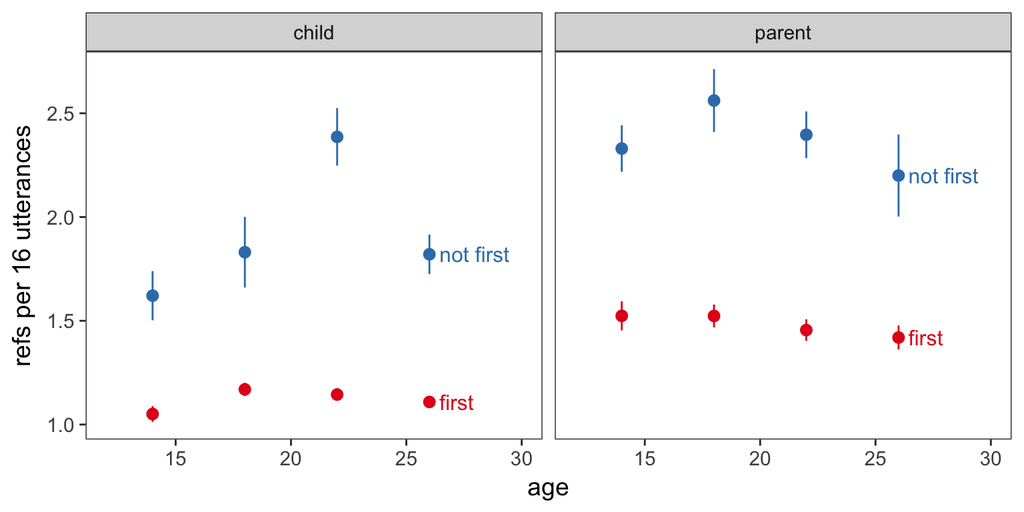

```r
sampled_subjs <- loaded_subjs %>%
  group_by(subj, age) %>%
  split_df(., 16, 30) %>%
  spread_refs()

#now want to see how many referents in the discourse are first referents and plot those averages
first_data <- coded_responses %>%
  group_by(subj, age, referent) %>%
  slice(1) %>%
  mutate(first = TRUE)

not_first_data <- coded_responses %>%
  group_by(subj, age, referent) %>%
  slice(2:nrow(.)) %>%
  mutate(first = FALSE)

first_ref <- sampled_subjs %>%
  mutate(isFirst = ifelse(time2 %in% first_data$time2, "first","not first")) %>%
  group_by(subj, age, sample, isFirst, person, modality) %>%
  summarise(count=sum(is.na(referent)==FALSE))

first_ref_all <- first_ref %>%
  group_by(isFirst, age, person, subj) %>%
  summarise(count = mean(count)) %>%
  summarise(mean = mean(count, na.rm = T),
            sem = sem(count, na.rm = T))

first_ref_modality <- first_ref %>%
  group_by(isFirst, age, person, modality, subj) %>%
  summarise(count = mean(count)) %>%
  summarise(mean = mean(count, na.rm = T),
            sem = sem(count, na.rm = T))


ggplot(first_ref_all, aes(x = age, y = mean, color = isFirst, label = isFirst)) +
  facet_wrap(~person) +
  geom_pointrange(aes(ymin = mean - sem, ymax = mean+sem)) +
  ylab("refs per 16 utterances") +
  scale_color_brewer(palette = "Set1") +
  geom_dl(method = list(dl.trans(x=x +.2), "last.qp", cex=1)) +
  scale_x_continuous(limits = c(12, 30))
```

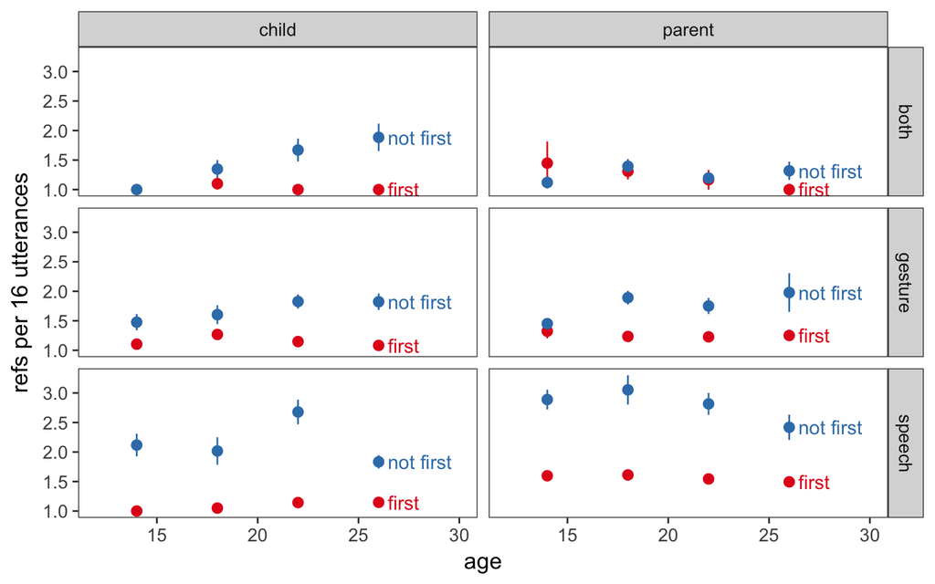

```r
ggplot(first_ref_modality, aes(x= age, y = mean, color = isFirst, label = isFirst)) +
  facet_grid(modality~person) +
  geom_pointrange(aes(ymin = mean - sem, ymax = mean+sem)) +
  ylab("refs per 16 utterances") +
  scale_color_brewer(palette = "Set1") +
  geom_dl(method = list(dl.trans(x=x +.2), "last.qp", cex=1)) +
  scale_x_continuous(limits = c(12, 30))
```

## Comparisons to previous discourse analyses

In the Frank et al discourse paper, they defined a discourse to be 3 or more continued references to the same referent. While this is a flawed definition of discourse, I was curious to see how many “discourses” were in our data set

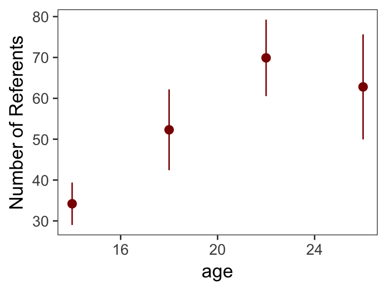

```r
discourse_amt <- coded_responses %>%
  mutate(lag_ref = lag(referent),
         lag_lag_ref = lag(lag_ref)) %>%
  filter(referent == lag_ref,
         lag_lag_ref == lag_ref) %>% #filter for strings of at least 3 same referent
  filter(referent != lag(referent)) %>% # grab first of each run
  group_by(subj, age, referent, time) %>%
  slice(1) %>%
  group_by(age, subj) %>%
  summarise(n = n()) %>%
  summarise(mean = mean(n), sem = sem(n))

ggplot(discourse_amt, aes(x = age, y= mean)) +
  geom_pointrange(aes(ymin = mean - sem, ymax = mean +sem), color = "darkred") +
  ylab("Number of Referents")
```

It seems like there are the most strings of at least 3 of same referent at age 22mos, not other months! However, we probably need to normalize by total number of refernts

How do these data compare to Frank et al? They used only speech data with a much smaller sample of referents, 5-15 minute lengths of play (how long are ours?) with a total corpus of 5,000 utterances (smaller) and found 6mos=88 discourse, 12mos=110, 18mos=107. We would expect them to have more repeated discourses because they have many fewer potential referents. This seems to be the case.

Here is a gleitman plot that is actually interpretable, for giving an example of what a discourse might look like in the data:

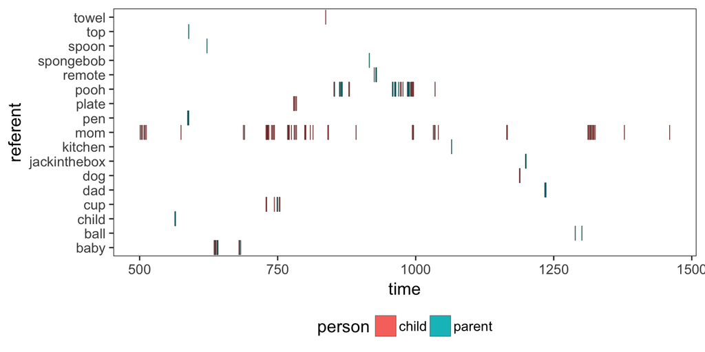

```r
discourse_2<-coded_responses %>%
  mutate(lag_ref=lag(referent),
         lag_lag_ref=lag(lag_ref)) %>%
  filter(referent==lag_ref, lag_lag_ref == lag_ref) %>% #filter for strings of at least 3 same referent
  group_by(subj, age, referent, time) %>%
  slice(1) %>%
  filter(subj==33, age==22, time >500) #arbitrary choice

ggplot(discourse_2, aes(x = time, y = referent, fill = person)) +
  geom_tile(color = "black") +
  theme(legend.position = "bottom")
```

## Discourse structure

Our main goal is to be able to predict what a discourse between a parent and child will look like. We therefore want to try and capture the parent and child’s purposes for communicating with each other. One way to do this is to develop a measure for whether a communicative act (speech or gesture) was successful.

Though this may not be the correct way to define it, here we look at how the subject and referent changes from one referent-containing utterance to the next to determine which of the following categories it belongs to.

**success** = referent stays the same but person changes (the parent and child are communicating about the same thing, there is mutual understanding)

**switch** = referent changes and person changes (potentially a measure of ignoring or shifted attention, may be complicated because we are only including pairs here, and there is a chance the subjects could return to the original referent after one extra utterance)

**repeat** = referent stays the same and person stays the same (subject is repeating themselves, perhaps to practice language or gain attention)

**same_per_switch** = referent changes and person stays the same (the person may have an attention shift, or may change referents to try and capture attention of other)

It may be useful to try looking at actual discourse data (for example, the sample data) which includes utterances without a concrete noun, but for now let’s look just at the coded_responses data, which includes all data that contains a referent.

```r
discourse_success <- coded_responses %>%
  mutate(isFirst = if_else(time2 %in% first_data$time2, "first", "not first")) %>%
  mutate(success = if_else(lag(person) != person & lag(referent) == referent, "success",
                          if_else(lag(person) != person & lag(referent) !=referent, "switch",
                                  if_else(lag(referent) == referent, "repeat",
                                          "same_per_swtich")))) %>%
  filter(!is.na(success)) #takes out first line of data so we have no NAs
```

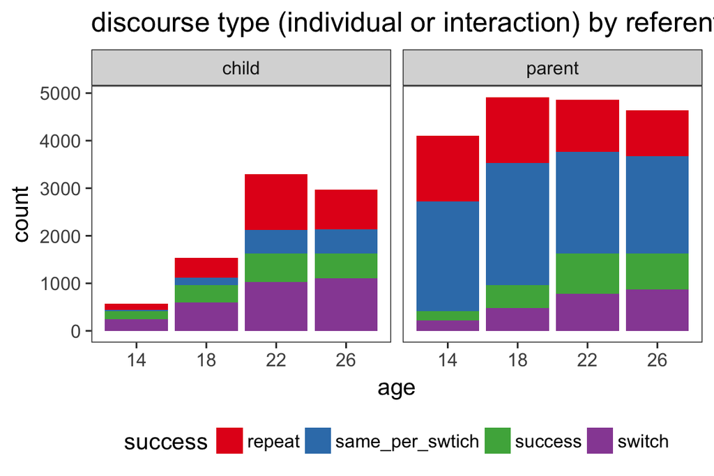

```r
ggplot(discourse_success, aes(x=age, fill=success)) +
  facet_wrap(~person)+
  geom_bar(position = "stack")+
  theme(legend.position="bottom") +
  scale_fill_brewer(palette = "Set1") +
  scale_x_continuous(breaks = unique(discourse_success$age)) +
  ggtitle("discourse type (individual or interaction) by referent stability (same or different)")
```

Does parent discourse responsiveness stay constant over age? Or is it larger for small children?

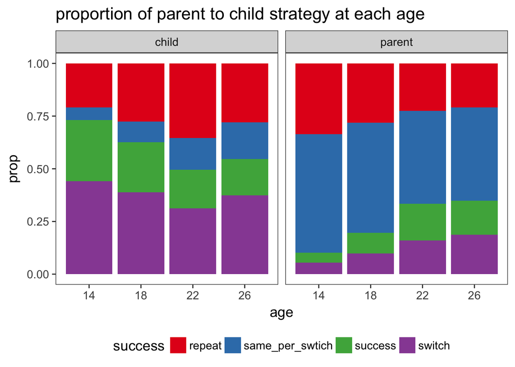

```r
discourse_prop <- discourse_success %>%
  group_by(age, person, success) %>%
  summarise(n=n()) %>%
  group_by(age, person) %>%
  mutate(prop= n/sum(n))

ggplot(discourse_prop, aes(x=age, y=prop, fill=success)) +
  facet_wrap(~person) +
  geom_bar(stat= "identity", position="stack") +
  theme(legend.position="bottom") +
  scale_fill_brewer(palette="Set1")+
  scale_x_continuous(breaks = unique(discourse_prop$age)) +
  ggtitle("proportion of parent to child strategy at each age")
```

Shows what proportion of time parents or children are spending with each kind of discourse (be careful about interpreting).

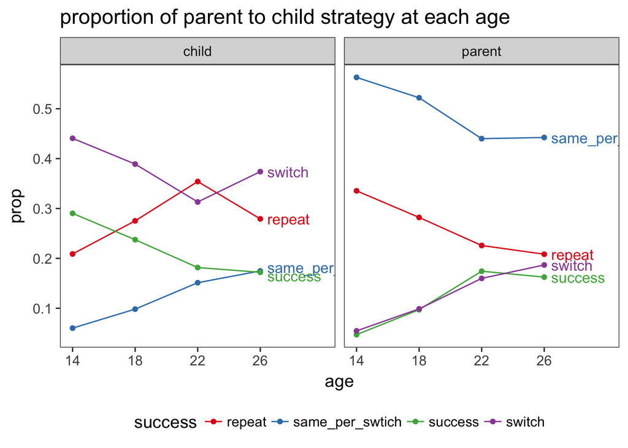

```r
ggplot(discourse_prop, aes(x=age, y=prop, color=success, label = success)) +
  facet_wrap(~person) +
  geom_line() +
  geom_point() +
  theme(legend.position="bottom") +
  scale_color_brewer(palette="Set1")+
  scale_x_continuous(breaks = unique(discourse_prop$age),
                     limits = c(14,30)) +
  geom_dl(method = list(dl.trans(x=x +.2), "last.qp", cex=1)) +
  ggtitle("proportion of parent to child strategy at each age")
```

What happens when the referent is first introduced into the session? How does that change the discourse type effects we have seen? This analysis is not meaningful mainly because of the way we defined discourse type (depends on the previous utterance). First references would only be applicable for referent switches.

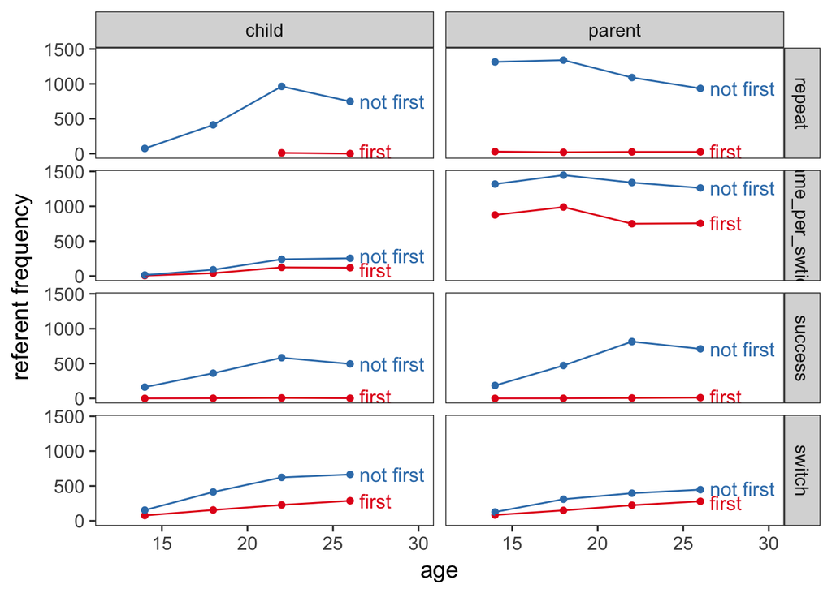

```r
first_success<-coded_responses %>%
  filter(referent != "mom") %>%
  mutate(isFirst = ifelse(time2 %in% first_data$time2, "first","not first")) %>%
  mutate(success = ifelse(lag(person) != person & lag(referent)==referent, "success", ifelse(lag(person) != person & lag(referent) !=referent, "switch", ifelse(lag(referent)==referent, "repeat", "same_per_swtich")))) %>%
  filter(is.na(success)==FALSE) %>%
  group_by(person, age, isFirst, success) %>%
  summarise(count = sum(is.na(referent)==FALSE))

ggplot(first_success, aes(x = age, y = count, color = isFirst, label = isFirst)) +
  facet_grid(success~person) +
  geom_point() +
  geom_line()+
  ylab("referent frequency") +
  scale_color_brewer(palette = "Set1")  +
  geom_dl(method = list(dl.trans(x=x +.2), "last.qp", cex=1)) +
  scale_x_continuous(limits = c(12, 30))
```

What about if we introduce modality into our discourse analysis? Are there any differences in the frequency of repetitions, same_per_switches, successes, or switches based on what modality the person is using?

There is a lot of information on these graphs, which makes them somewhat difficult to read. It seems like the use of modality is pretty consistent across type of discourse, except for children of age 14mos. There may be something interesting happening at that age point only.

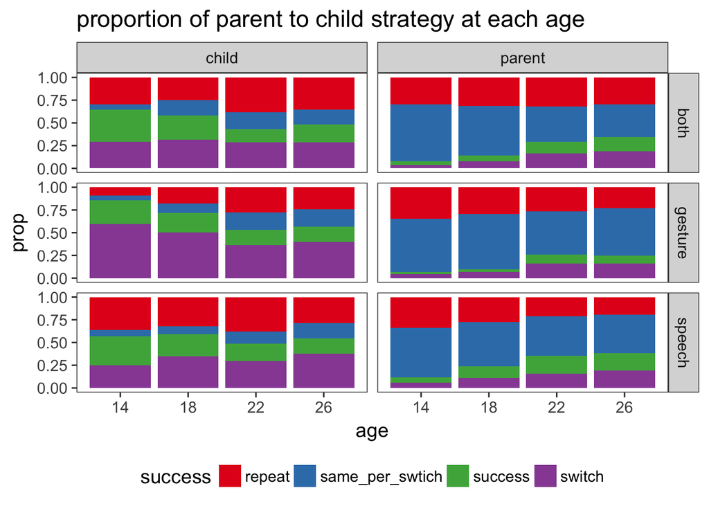

```r
discourse_modality_prop <- discourse_success %>%
  group_by(age, person, modality, success) %>%
  summarise(n=n()) %>%
  group_by(age, person, modality) %>%
  mutate(prop= n/sum(n))

ggplot(discourse_modality_prop, aes(x=age, y=prop, fill=success)) +
  facet_grid(modality~person) +
  geom_bar(stat="identity", position="stack") +
  theme(legend.position="bottom") +
  scale_fill_brewer(palette="Set1")+
  scale_x_continuous(breaks = unique(discourse_prop$age)) +
  ggtitle("proportion of parent to child strategy at each age")
```

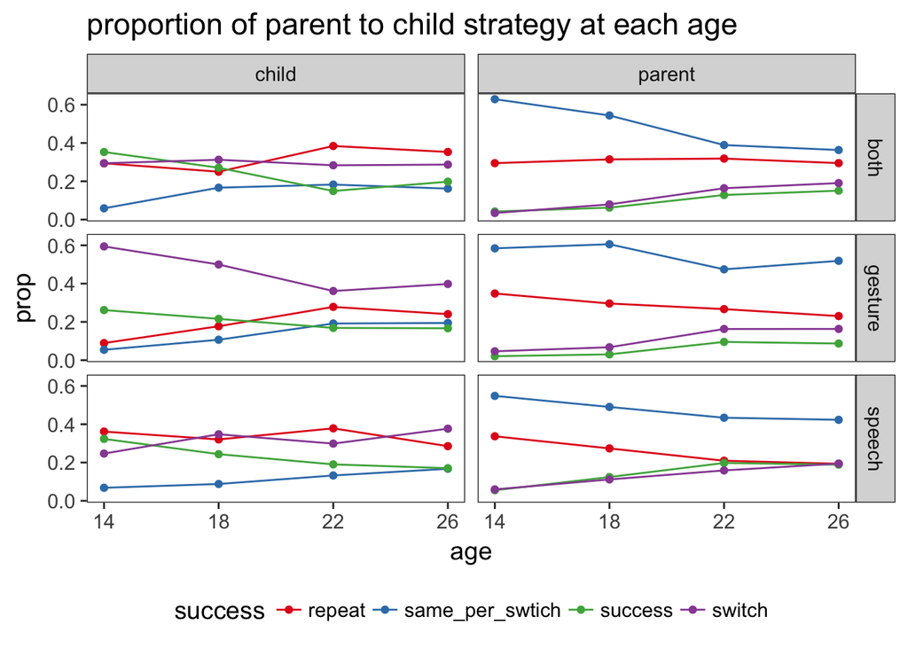

```r
ggplot(discourse_modality_prop, aes(x=age, y=prop, color=success)) +
  facet_grid(modality~person) +
  geom_line() +
  geom_point() +
  theme(legend.position="bottom") +
  scale_color_brewer(palette="Set1")+
  scale_x_continuous(breaks = unique(discourse_prop$age)) +
  ggtitle("proportion of parent to child strategy at each age")
```

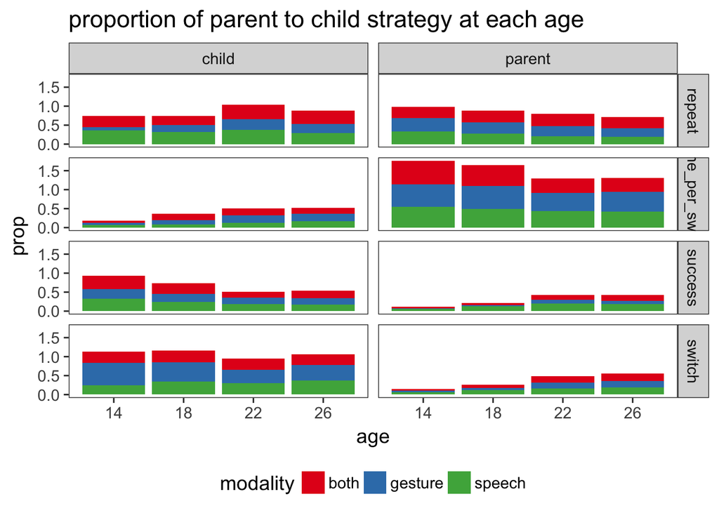

```r
ggplot(discourse_modality_prop, aes(x=age, y=prop, fill=modality)) +
  facet_grid(success~person) +
  geom_bar(stat="identity", position="stack") +
  theme(legend.position="bottom") +
  scale_fill_brewer(palette="Set1")+
  scale_x_continuous(breaks = unique(discourse_prop$age)) +
  ggtitle("proportion of parent to child strategy at each age")
```

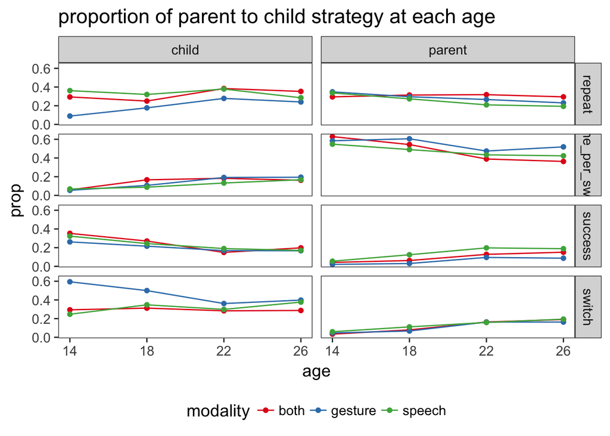

```r
ggplot(discourse_modality_prop, aes(x=age, y=prop, color=modality)) +
  facet_grid(success~person) +
  geom_line() +
  geom_point() +
  theme(legend.position="bottom") +
  scale_color_brewer(palette="Set1")+
  scale_x_continuous(breaks = unique(discourse_prop$age)) +
  ggtitle("proportion of parent to child strategy at each age")
```

What is the purpose of repetition for children? Are they using it simply to practice a recently-learned word, or are they using it as an attention-getting mechanism?

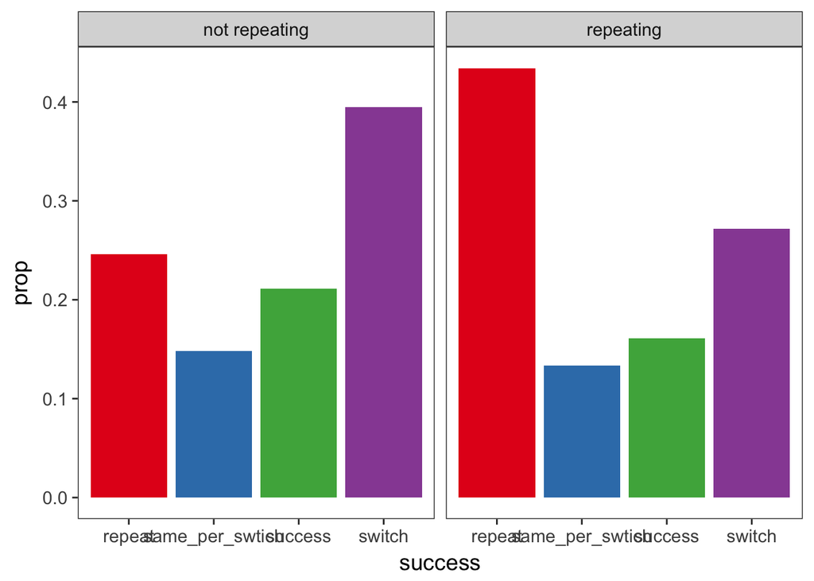

```r
repeat_data <- discourse_success %>%
  filter(person == "child")%>%
  mutate(rep = ifelse(lag(success) == "repeat", "repeating", "not repeating")) %>%
  filter(is.na(rep)==FALSE) %>%
  group_by(rep, success) %>%
  summarise(n=n()) %>%
  mutate(prop = n/sum(n))

ggplot(aes(x=success, y=prop, fill = success), data=repeat_data)+
  geom_bar(stat="identity")+
  scale_fill_brewer(palette = "Set1") +
  facet_wrap(~rep)
```

They do seem to do a lot of repeating…